# Vw_sim_plots

Manas GA

2024-12-17

```r
library(ggplot2)
library(cowplot)
library(latex2exp)
options(scipen = 999) # Avoid scientific numbers such as 1e+5
```

The following code loads outputs of simulation analyses and makes figures for the manuscript. Simulation data is classified into sets, with the sets that are useful for the manuscript being as follows (the number of simulations within each set are indicated inside brackets):

- Set_18 (900 simulations): All simplified simulations
- Set_9 (100 simulations, each analysed in three different ways): The standard set for full simulations
- Set_11 (100): Full simulations with 0.02 % beneficial mutations
- Set_14 (100): Full simulations with 2 % beneficial mutations
- Set_12 (200): Full simulations varying map length in th experiment
- Set_13 (176): Full simulations varying map length in history
- Set_15 (200): Full simulations varying the scale
- Set_N1 (396): Full simulations varying the map length in history (for simulations in which scale = 0.045)
- Set_16 (100): Testing B&C - simplified simulations with 50 replicate populations and map length in history = c(0.5, 5, 50, 100)
- Set_17 (69): Testing B&C - full simulations with 50 replicate populations and map length in history = c(0.5, 5, 50, 100)
- Set_23 (300): Simplified simulations with dominance (k %in% c(0, 0.5, 0.9))
- Set_25 (300): Full simulations with dominance (k %in% c(0, 0.5, 0.75)) at map length in history = 0.5 morgan
- Set_31 (300): Full simulations with dominance (k %in% c(0, 0.5, 0.9)) only in the experiment phase at map length in history = 0.5 morgan
- Set_32 (300): Full simulations with dominance (k %in% c(0, 0.5, 0.9)) at map length in history = 5 morgans

## Set paths

```r
### On Manas's PC ###

# All data used for plotting exists in this repository in the directory: "Va_simulations/5_Manuscript_files/combined_data"

data_path = "../5_Manuscript_files/combined_data"
output_path = "../5_Manuscript_files/Manuscript_figures"
```

## Function to remove duplication

Some simulations were erroneously analysed twice. The following function takes a data frame for a set of simulations as input, and if there are any simulations analysed twice, retains the analysis performed earlier in time.

```r
deduplicate_sim_analyses = function(data_frame){

  for (set_id in unique(data_frame$Set_ID)){

    count = sum(data_frame$Set_ID == set_id)

    if(count>1){
      data_sim = data_frame[data_frame$Set_ID==set_id,]

      # Remove the nodename and the year from the analysis stamp and then identify the analysis which was performed later

      max_time = max(sub(".*_2025-", "",  data_sim$analysis_stamp))
      analysis_to_be_deleted = data_sim$analysis_stamp[grep(max_time, data_sim$analysis_stamp)]

      # Delete this analysis

      data_frame = data_frame[data_frame$analysis_stamp!=analysis_to_be_deleted,]

    }

  }

  return(data_frame)

}
```

## Function to add recalculated true V_A (V_A_true_new), lost_va to a dataframe

These calculations were performed at a later stage and are stored in a separate file (“/new_va_calculation_combined.csv”). For every simulation in the input dataframe this functions looks up the row with the appropriate Set_ID in “new_va_calculation_combined.csv” and adds the V_A_true_new and other data pertaining to lost_va to the input dataframe.

```r
add_new_va_data = function(new_va_data,    # Data frame storing the calculations of vA_true_new, lost_va, etc
                           target_data,    # Target dataframe to which this information is to be added
                           verbose = FALSE){

  # Create empty columns in the target data

  target_data$vA_true_new = NA
  target_data$va_true_new = NA
  target_data$va_left = NA
  target_data$va_left_new = NA

  for(set_id in target_data$Set_ID){

    # Check if the set_id exists in new_va_data

   if(!set_id%in%new_va_data$Set_ID){
     if(verbose){warning(paste("Simulation ", set_id, " is missing from new_va_calculation_combined.csv", sep = ""))}
   }else{

      # Add data to target_data
      target_data[target_data$Set_ID == set_id,]$vA_true_new = new_va_data[new_va_data$Set_ID == set_id,]$vA_true_new[1]
      target_data[target_data$Set_ID == set_id,]$va_true_new = new_va_data[new_va_data$Set_ID == set_id,]$va_true_new[1]
      target_data[target_data$Set_ID == set_id,]$va_left = new_va_data[new_va_data$Set_ID == set_id,]$va_left[1]
      target_data[target_data$Set_ID == set_id,]$va_left_new = new_va_data[new_va_data$Set_ID == set_id,]$va_left_new[1]

     }



  }
  return(target_data)
}
```

## Function to make “standard” plot

```r
make_std_plots = function(data,
                          font_size = 15,
                          end_gen = 25000,
                          data_in_title = FALSE){

  # vA_est ~ vA_true

p_main = ggplot(data, aes(y = vA_est, x = vA_true_new)) +
  theme_bw() +
  geom_point() +
  geom_abline(intercept = 0, slope = 1) +
  labs(x = TeX(r"(True $V_A$)"), y = TeX(r"(Estimate of $V_A$)")) +
  theme(text = element_text(size = font_size))

# palpha_est histogram

p_palpha = ggplot(data, aes(x = palpha_est)) +
  theme_bw() +
  geom_histogram(color = "black", fill = "white") +
  labs(x = TeX(r"(Estimate of $p_{\alpha} $)"), y = "Frequency") +
  geom_vline(xintercept = 0, color = "red") +
  geom_vline(xintercept = mean(data$palpha_est), linetype = "dashed") +
  theme(text = element_text(size = font_size))

# Residual variance

p_res_var = ggplot(data, aes(x = Residual_var)) +
  theme_bw() +
  geom_histogram(color = "black", fill = "white") +
  labs(x = "Residual variance", y = "Frequency") +
  geom_vline(xintercept = 1, color = "red") +
  geom_vline(xintercept = mean(data$Residual_var), linetype = "dashed") +
  theme(text = element_text(size = font_size))

# balpha_slope_est histogram

p_balpha_slope = ggplot(data, aes(x = balpha_slope_est)) +
  theme_bw() +
  geom_histogram(color = "black", fill = "white") +
  labs(x = TeX(r"(Estimate of $\beta^{(1)}_{\bar{\alpha}}$)"), y = "Frequency") +
  geom_vline(xintercept = 0, color = "red") +
  geom_vline(xintercept = mean(data$balpha_slope_est), linetype = "dashed") +
  theme(text = element_text(size = font_size))

# Combine the four plots

p_combined = plot_grid(p_main, p_palpha, p_balpha_slope, p_res_var, labels = "auto")

if(data_in_title){

  # Title

  ml = unique(data$sequence_length*data$r)
  if(length(ml)>1){stop("The data set does not have the same map length in the burnin phase in every simulation.")}

  ml_expt = unique(data$sequence_length*data$r_expt)
  if(length(ml_expt)>1){stop("The data set does not have the same map length in the experiment in every simulation.")}

  end_gen = unique(data$end_gen)
  if(length(end_gen)>1){stop("The data doe not have have the same end_gen for every simulations")}

  if(end_gen==2){
    ml = unique(data$sequence_length*data$r_msp)
    if(length(ml)>1){stop("The data set does not have the same map length in the burnin phase in every simulation.")}
  }else{
    ml = unique(data$sequence_length*data$r)
    if(length(ml)>1){stop("The data set does not have the same map length in the burnin phase in every simulation.")}
  }

  mu_alpha = (data$shape)*(data$shape)

  title = ggdraw() + draw_label(paste("Map length in burnin = ", ml, " M, Map length in experiment = ", ml_expt, " M, scale = ", data$scale, sep = ""), hjust = 0.5, size = font_size)

  # Add title
  p_combined = plot_grid(title, p_combined, ncol = 1, rel_heights = c(0.1,1))

}

return(list(main = p_main, palpha = p_palpha, res_var = p_res_var, balpha_slope = p_balpha_slope,
            combined = p_combined))


}
```

Load the dataframe storing information on calculations of vA_true_new, va_true_new, va_lost, va_lost_new

```r
d_new_va = read.csv(file.path(data_path, "new_va_calculation_combined.csv"))
```

## Simplified simulations (simulations without burnin) (Set_18) (Figure 1, Figure 2)

Selection coefficients were drawn from a gamma distribution (shape = 0.3, scale = 0.033) and assigned to mutations randomly. The recombination rate in the msprime simulation was 5.32e-07. Map length in the history phase of just 1 generation (eng_gen = 2) was 5.

Standard parameters:

Map length in the experiment phase (ml_exp) = 2 M Number of individuals in the experiment (n_ind_exp) = 1000 Number of cages (n_cages) = 10 ngen2 = 4

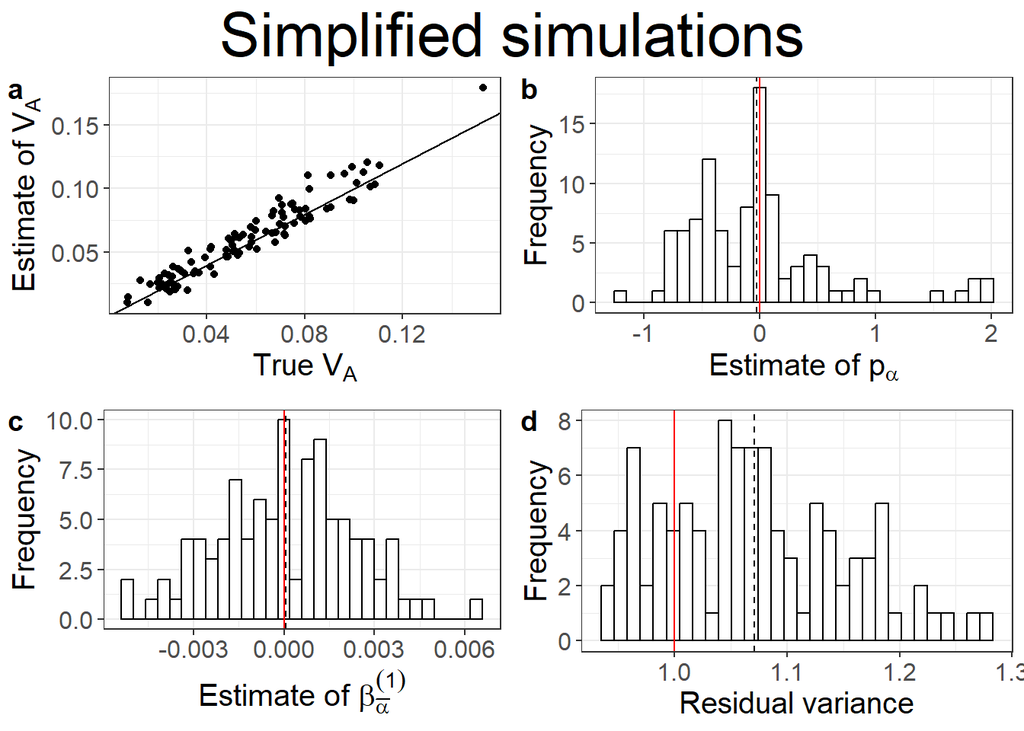

```r
d_18 = read.csv(file.path(data_path, "Set_18_corrected_output.csv"))


# Add calculations of vA_true_new, va_true_new, va_lost, va_lost_new
d_18 = add_new_va_data(new_va_data=d_new_va, target_data=d_18, verbose=TRUE)

# Filter out the data where allele frequencies are sampled using simulate_pool_seq()

d_18 = d_18[grep("pool_seq", d_18$analysis_stamp, invert = TRUE, value = FALSE),]
d_18 = deduplicate_sim_analyses(d_18)

# Select data for the standard plot for simplified simulations
d_18_std = d_18[d_18$r_expt*d_18$sequence_length==2&d_18$n_ind_exp==1000&d_18$n_cages==10&d_18$ngen2==4,] # Data for the standard set

##################################################################################################
####### Standard plots (Set_5: ml_expt = 2, n_indxpt = 1000, n_cages = 10, ngen2 = 4) ############
##################################################################################################

################
### Figure 1 ###
################

p_nb_2_std = make_std_plots(d_18_std)$combined
title = ggdraw() + draw_label("Simplified simulations", hjust = 0.5, size = 30)
p_nb_2_std = plot_grid(title, p_nb_2_std, ncol = 1, rel_heights = c(0.1,1))


ggsave(p_nb_2_std, width = 8, height = 8, file = file.path(output_path, "simplified_main.pdf"))
p_nb_2_std
```

We then vary map length in the experiment (ml_exp), population size in the experiment (n_ind_exp), the number of replicate populations (n_cages), and the generation when the experiment ends (ngen2) (ngen1 is set to 1 in the simulations) one at a time while keeping the other parameters fixed at their standard values.

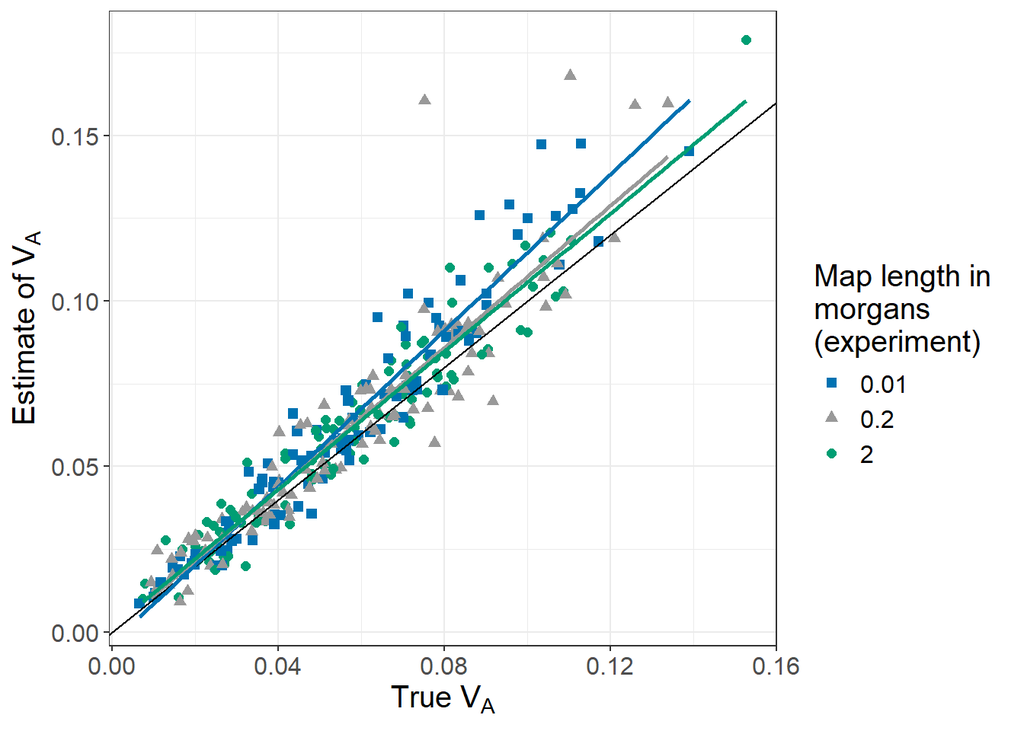

```r
################
### Figure 2 ###
################

# The legends and plot windows are combined using plot_grid() in cowplot to ensure that all plot windows and legends have the same sizes for all plots irrespective of the length of the legend label

### ml_exp ###

d_18_ml_exp = d_18[d_18$n_ind_exp==1000&d_18$n_cages==10&d_18$ngen2==4,]
p_nb_2_ml_exp = ggplot(d_18_ml_exp, aes(y=vA_est, x = vA_true_new, color = factor(sequence_length*r_expt), shape = factor(sequence_length*r_expt))) +
  theme_bw() +
  geom_point(size = 2) +
  geom_abline(intercept = 0, slope = 1) +
  labs(x = TeX(r"(True $V_A$)"), y = TeX(r"(Estimate of $V_A$)"), color = "Map length in\nmorgans \n(experiment)", shape = "Map length in\nmorgans \n(experiment)") +
  scale_color_manual(values = c("#0072B2", "#999999", "#009E73")) + scale_shape_manual(values = c(15, 17, 16)) +
  theme(text = element_text(size = 15)) +
  geom_smooth(method = "lm", se=FALSE, show.legend = FALSE)

legend_nb_2_ml_exp = get_legend(p_nb_2_ml_exp)
p_nb_2_ml_exp = plot_grid(p_nb_2_ml_exp + theme(legend.position = "none"),
                      legend_nb_2_ml_exp,
                      ncol = 2,
                      rel_widths = c(1.0, 0.3))
p_nb_2_ml_exp
```

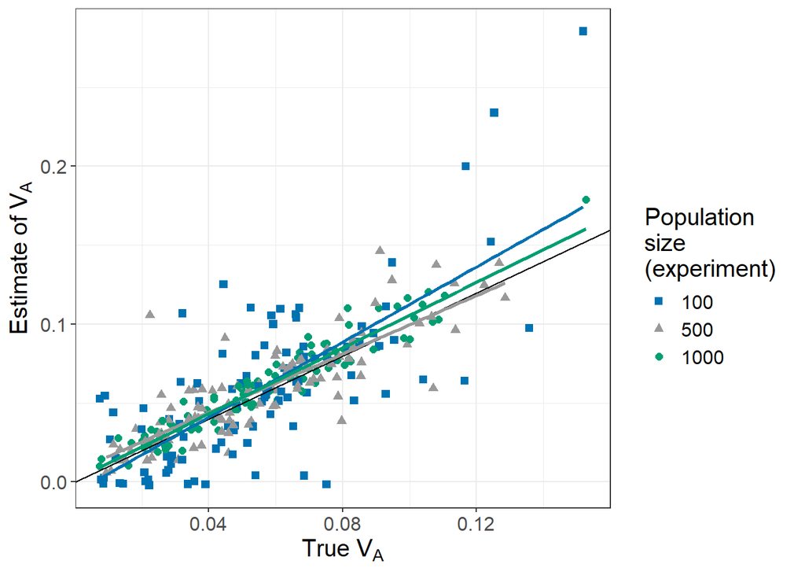

```r
### n_ind_exp ###
d_18_nind = d_18[d_18$r_exp==2e-6&d_18$n_cages==10&d_18$ngen2==4,]
p_nb_2_nind = ggplot(d_18_nind , aes(y=vA_est, x = vA_true_new, color = factor(n_ind_exp), shape = factor(n_ind_exp))) +
  theme_bw() +
  geom_point(size = 2) +
  geom_abline(intercept = 0, slope = 1) +
  labs(x = TeX(r"(True $V_A$)"), y = TeX(r"(Estimate of $V_A$)"), color = "Population \nsize \n(experiment)", shape = "Population \nsize \n(experiment)") +
  scale_color_manual(values = c("#0072B2", "#999999", "#009E73")) + scale_shape_manual(values = c(15, 17, 16)) +
  theme(text = element_text(size = 15)) +
  geom_smooth(method = "lm", se=FALSE, show.legend = FALSE)

legend_nb_2_nind = get_legend(p_nb_2_nind)
p_nb_2_nind = plot_grid(p_nb_2_nind + theme(legend.position = "none"),
                        legend_nb_2_nind,
                        ncol = 2,
                        rel_widths = c(1.0, 0.3))
p_nb_2_nind
```

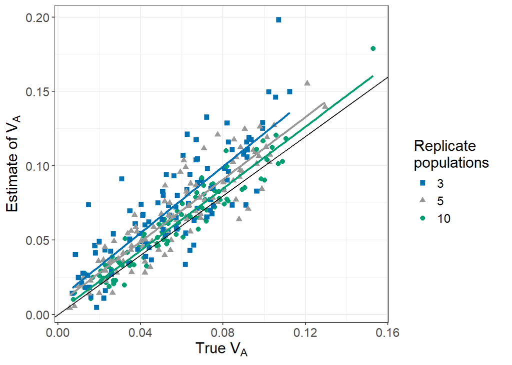

```r
### n_cages ###

d_18_ncages = d_18[d_18$r_exp==2e-6&d_18$n_ind_exp==1000&d_18$ngen2==4,]
p_nb_2_ncages = ggplot(d_18_ncages , aes(y=vA_est, x = vA_true_new, color = factor(n_cages), shape = factor(n_cages))) +
  theme_bw() +
  geom_point(size = 2) +
  geom_abline(intercept = 0, slope = 1) +
  labs(x = TeX(r"(True $V_A$)"), y = TeX(r"(Estimate of $V_A$)"), color = "Replicate \npopulations", shape = "Replicate \npopulations") +
  scale_color_manual(values = c("#0072B2", "#999999", "#009E73")) + scale_shape_manual(values = c(15, 17, 16)) +
  theme(text = element_text(size = 15)) +
  geom_smooth(method = "lm", se=FALSE, show.legend = FALSE)

legend_nb_2_ncages = get_legend(p_nb_2_ncages)
p_nb_2_ncages = plot_grid(p_nb_2_ncages + theme(legend.position = "none"),
                          legend_nb_2_ncages,
                          ncol = 2,
                          rel_widths = c(1.0, 0.3))
p_nb_2_ncages
```

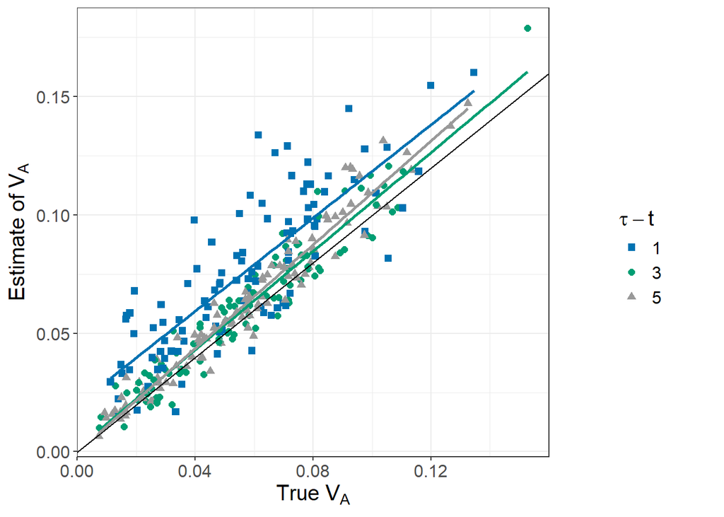

```r
### ngen_expt ###

d_18_ngen2 = d_18[d_18$r_exp==2e-6&d_18$n_ind_exp==1000&d_18$n_cages==10,]
p_nb_2_ngen2 = ggplot(d_18_ngen2 , aes(y=vA_est, x = vA_true_new, color = factor(ngen2-ngen1), shape = factor(ngen2-ngen1))) +
  theme_bw() +
  geom_point(size = 2) +
  geom_abline(intercept = 0, slope = 1) +
  labs(x = TeX(r"(True $V_A$)"), y = TeX(r"(Estimate of $V_A$)"), color = TeX(r"($\tau - t$)"), shape = TeX(r"($\tau - t$)")) +
  scale_color_manual(values = c("#0072B2", "#009E73", "#999999")) + scale_shape_manual(values = c(15, 16, 17)) +
  theme(text = element_text(size = 15)) +
  geom_smooth(method = "lm", se=FALSE, show.legend = FALSE)

legend_nb_2_ngen2 = get_legend(p_nb_2_ngen2)
p_nb_2_ngen2 = plot_grid(p_nb_2_ngen2 + theme(legend.position = "none"),
                         legend_nb_2_ngen2,
                         ncol = 2,
                         rel_widths = c(1.0, 0.3))
p_nb_2_ngen2
```

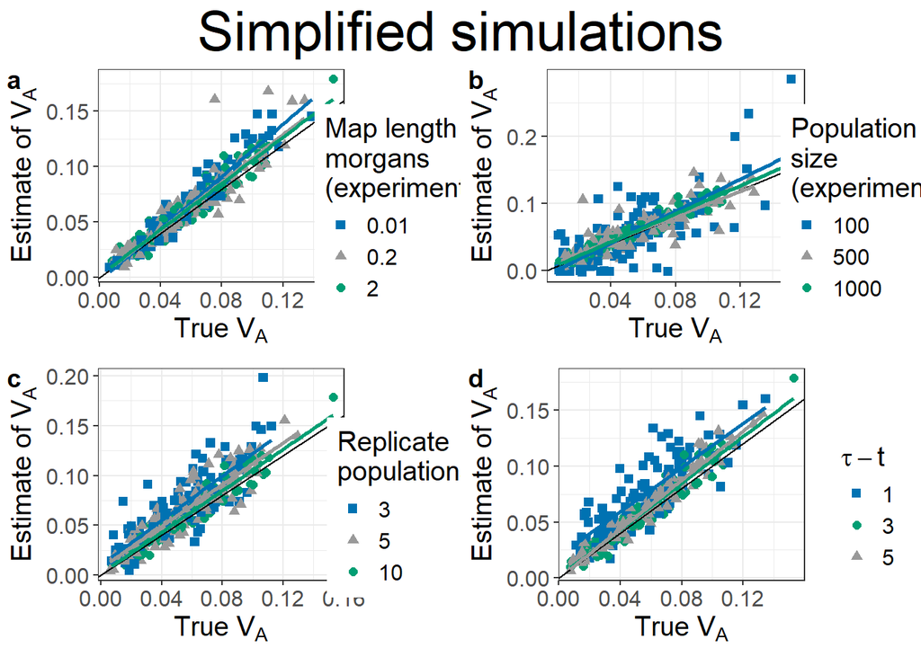

```r
### Combine the plots ###

p_nb_2_combined = plot_grid(p_nb_2_ml_exp, p_nb_2_nind, p_nb_2_ncages, p_nb_2_ngen2, labels = "auto")

title = ggdraw() + draw_label("Simplified simulations", hjust = 0.5, size = 30)

# Add title
p_nb_2_combined = plot_grid(title, p_nb_2_combined, ncol = 1, rel_heights = c(0.1,1))

p_nb_2_combined
```

```r
ggsave(p_nb_2_combined, width = 12, height = 10, file = file.path(output_path, "simplified_params.pdf"))
```

### Simplified simulations with dominance

```r
d_23 = read.csv(file.path(data_path, "Set_23_corrected_output.csv"))
d_23 = add_new_va_data(new_va_data=d_new_va, target_data=d_23, verbose=TRUE)
d_23$k = gsub(".*=", x=d_23$sim, "")

# Since the ylabels have different widths, the combined plot dows not have the four panels properly aligned
# Draw the yabels separately to pre-specified dimensions and then combine the y_label-less plots with the custom y-labels

### Main estimate vs true V_A ###

p_nb_dom_main = ggplot(d_23, aes(y = vA_est, x = vA_true_new, color = k, shape = k)) +
  theme_bw() + geom_point(size = 2) +
  labs(x = TeX(r"(True $V_A$)"), y = TeX(r"(Estimate of $V_A$)"), color = TeX(r"(Degree of dominance $(|\kappa|)$)"), shape = TeX(r"(Degree of dominance $(|\kappa|)$)")) +
  theme(text = element_text(size = 15))+
  scale_color_manual(values = c("#009E73","#0072B2", "#999999")) +
  geom_abline(slope = 1, intercept = 0) +
 theme(legend.position = "bottom") +
  geom_smooth(method = "lm", se=FALSE, show.legend = FALSE)

# Save the legend
legend_nb_dominance = get_plot_component(p_nb_dom_main + guides(color = guide_legend(nrow = 1)) + theme(legend.position = "bottom"), "guide-box-bottom")
label_nb_dom_main = ggdraw() + draw_label(TeX(r"(Estimate of $V_A$)"), x = 0.5, y = 0.5, angle = 90, vjust = 0.5, hjust = 0.5, fontface = "bold", size = 15)

p_nb_dom_main = plot_grid(label_nb_dom_main,
                          p_nb_dom_main + labs(y = NULL) + theme(legend.position = "none"),
                          ncol = 2, rel_widths = c(0.1, 1))
### Boxplot for p_{alpha} ###

p_nb_dom_palpha = ggplot(d_23, aes(y = palpha_est, x = k, fill = k)) +
  theme_bw() + geom_boxplot() +
  labs(x = TeX(r"(Degree of dominance $(|\kappa|)$)"), y = TeX(r"(Estimate of $p_{\alpha} $)"), fill = TeX(r"(Degree of dominance $(|\kappa|)$)")) +
  theme(text = element_text(size = 15))+
  scale_fill_manual(values = c("#009E73", "#0072B2",  "#999999")) +
  geom_abline(slope = 0, intercept = 0, linetype = "dotdash") +
 theme(legend.position = "bottom")

label_nb_dom_palpha = ggdraw() + draw_label(TeX(r"(Estimate of $p_{\alpha} $)"), x = 0.5, y = 0.5, angle = 90, vjust = 0.5, hjust = 0.5, fontface = "bold", size = 15)

p_nb_dom_palpha = plot_grid(label_nb_dom_palpha,
                          p_nb_dom_palpha + labs(y = NULL) + theme(legend.position = "none"),
                          ncol = 2, rel_widths = c(0.1, 1))

### Boxplot for B_{alpha}^{(1) ###

p_nb_dom_balpha_slope = ggplot(d_23, aes(y = balpha_slope_est, x = k, fill = k)) +
  theme_bw() + geom_boxplot() +
  labs(x = TeX(r"(Degree of dominance $(|\kappa|)$)"), y = TeX(r"(Estimate of $\beta^{(1)}_{\bar{\alpha}}$)"), fill = TeX(r"(Degree of dominance $(|\kappa|)$)")) +
  theme(text = element_text(size = 15))+
  scale_fill_manual(values = c("#009E73", "#0072B2",  "#999999")) +
  geom_abline(slope = 0, intercept = 0, linetype = "dotdash") +
 theme(legend.position = "bottom")

label_nb_dom_balpha_slope = ggdraw() + draw_label(TeX(r"(Estimate of $\beta^{(1)}_{\bar{\alpha}}$)"), x = 0.5, y = 0.5, angle = 90, vjust = 0.5, hjust = 0.5, fontface = "bold", size = 15)

p_nb_dom_balpha_slope = plot_grid(label_nb_dom_balpha_slope,
                          p_nb_dom_balpha_slope + labs(y = NULL) + theme(legend.position = "none"),
                          ncol = 2, rel_widths = c(0.1, 1))

### Residual variance ###

p_nb_dom_res_var = ggplot(d_23, aes(y = Residual_var, x = k, fill = k)) +
  theme_bw() + geom_boxplot() +
  labs(x = TeX(r"(Degree of dominance $(|\kappa|)$)"), y = "Residual variance", fill = TeX(r"(Degree of dominance $(|\kappa|)$)")) +
  theme(text = element_text(size = 15))+
  scale_fill_manual(values = c("#009E73", "#0072B2",  "#999999")) +
  geom_abline(slope = 0, intercept = 1, linetype = "dotdash") +
 theme(legend.position = "bottom")

label_nb_dom_res_var = ggdraw() + draw_label("Residual variance", x = 0.5, y = 0.5, angle = 90, vjust = 0.5, hjust = 0.5, size = 15)

p_nb_dom_res_var = plot_grid(label_nb_dom_res_var,
                          p_nb_dom_res_var + labs(y = NULL) + theme(legend.position = "none"),
                          ncol = 2, rel_widths = c(0.1, 1))

### Combine the four plots ###

p_nb_dominance_combined = plot_grid(p_nb_dom_main + theme(legend.position = "none"),
                                    p_nb_dom_palpha + theme(legend.position = "none"),
                                    p_nb_dom_balpha_slope + theme(legend.position = "none"),
                                    p_nb_dom_res_var + theme(legend.position = "none"),
                                    labels = "auto", nrow = 2)
title_nb_dominance = ggdraw() + draw_label("Simplified simulations", hjust = 0.5, size = 30)

p_nb_dominance_combined = plot_grid(title_nb_dominance,
                                    p_nb_dominance_combined,
                                    legend_nb_dominance,
                                    nrow = 3, rel_heights = c(0.2, 2, 0.1))

# ggsave(p_nb_dominance_combined, width = 8, height = 8, file = file.path(output_path, "simplified_dominance.pdf"))
```

## Full simulations with a burnin phase of 25000 generations

### Set 9 (larger simulations (scale = 0.033): ml = 0.5, ml_exp = 2) (Figure 3)

The standard set for full simulations.

Selection coefficients were drawn from a gamma distribution (shape = 0.3, scale = -0.033) and assigned to mutations randomly. No beneficial mutations. The forward simulation in the history phase was run for 25000 generations. The recombination rate in the msprime simulation was 5.32e-07. Map length in the history phase was 0.5 M, and the map length in the experiment was 2 M.

Number of individuals in the experiment (n_ind_exp) = 1000 Number of cages (n_cages) = 10 ngen2 = 4

The analyses for this set were performed using all.gp = FALSE and using the true N_E (i.e. using predict_Ne = TRUE)

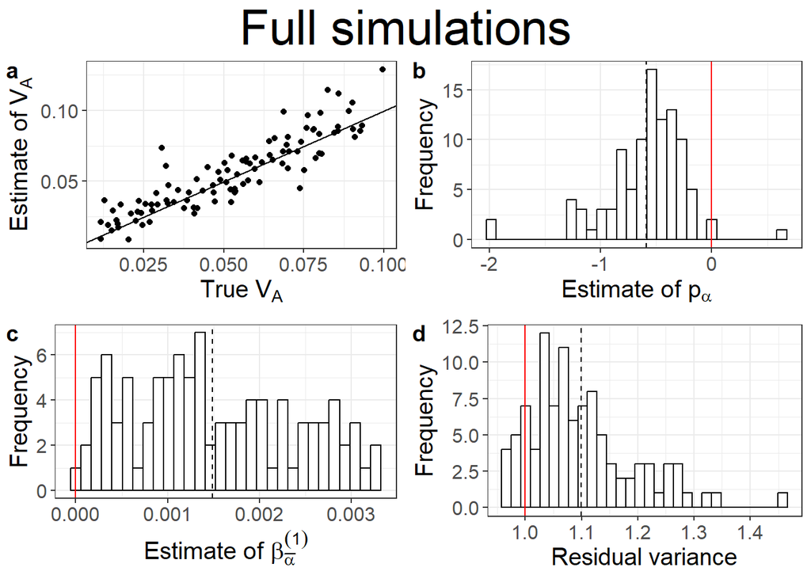

```r
################
### Figure 3 ###
################

d_9 = read.csv(file.path(data_path, "Set_9_corrected_output.csv")) # Data for the standard set

# Add calculations of vA_true_new, va_true_new, va_lost, va_lost_new
d_9 = add_new_va_data(new_va_data=d_new_va, target_data=d_9, verbose=TRUE)
# Remove the pool_seq data
d_9 = d_9[grep("pool_seq", d_9$analysis_stamp, invert = TRUE, value = FALSE),]

# Set 9 simulations were also renanalysed setting Ne_exp to c(1000, 1000) and setting all.gp = FALSE. Removing those rows.
d_9_std = d_9[d_9$all.gp==FALSE&d_9$Ne_exp!="1000_1000",]

p_b_std = make_std_plots(d_9_std)$combined
title = ggdraw() + draw_label("Full simulations", hjust = 0.5, size = 30)

p_b_std = plot_grid(title, p_b_std, ncol = 1, rel_heights = c(0.1,1))

ggsave(plot = p_b_std, width = 8, height = 8, file = file.path(output_path, "full_main.pdf"))
p_b_std
```

### Full simulations with dominance

```r
### Reference map length in history: 0.5 morgan ###

d_25 = read.csv(file.path(data_path, "Set_25_corrected_output.csv"))

# Remove analyses with LDalpha = TRUE
d_25 = d_25[d_25$LDalpha==FALSE,]

d_25 = add_new_va_data(new_va_data=d_new_va, target_data=d_25, verbose=TRUE)
d_25$k = gsub(".*=", x=d_25$sim, "")

p_b_dom_0.5 = ggplot(d_25, aes(y = vA_est, x = vA_true_new, color = k, shape = k)) +
  theme_bw() + geom_point(size = 2) +
  labs(x = TeX(r"(True $V_A$)"), y = TeX(r"(Estimate of $V_A$)"), color = TeX(r"(Degree of dominance $(|\kappa|)$)"), shape = TeX(r"(Degree of dominance $(|\kappa|)$)"), title = "0.5 morgan") +
  theme(text = element_text(size = 15)) +
  scale_color_manual(values = c("#009E73","#0072B2", "#D01C8B")) + scale_shape_manual(values = c(16, 17, 3)) +
  geom_abline(slope = 1, intercept = 0) +
 theme(legend.position = "bottom") +
  geom_smooth(method = "lm", se=FALSE, show.legend = FALSE) +
  theme(plot.title = element_text(hjust = 0.5), plot.subtitle = element_text(hjust = 0.5, size = 12))

# Save the legend
legend_b_dominance = get_plot_component(p_b_dom_0.5 + guides(color = guide_legend(nrow = 1)) + theme(legend.position = "bottom"), "guide-box-bottom")
# Low map length resulted in large LD!!!!

### Higher map length in history: 5 morgans ###

d_32 = read.csv(file.path(data_path, "Set_32_corrected_output.csv"))
d_32 = add_new_va_data(new_va_data=d_new_va, target_data=d_32, verbose=TRUE)
d_32$k = gsub(".*=", x=d_32$sim, "")

p_b_dom_5 = ggplot(d_32, aes(y = vA_est, x = vA_true_new, color = k, shape = k)) +
  theme_bw() + geom_point(size = 2) +
  labs(x = TeX(r"(True $V_A$)"), y = TeX(r"(Estimate of $V_A$)"), color = TeX(r"(Degree of dominance $(|\kappa|)$)"), shape = TeX(r"(Degree of dominance $(|\kappa|)$)"), title = "5 morgans") +
  theme(text = element_text(size = 15))+
  scale_color_manual(values = c("#009E73","#0072B2", "#D01C8B")) + scale_shape_manual(values = c(16, 17, 3)) +
  geom_abline(slope = 1, intercept = 0) +
 theme(legend.position = "bottom") +
  geom_smooth(method = "lm", se=FALSE, show.legend = FALSE) +
  theme(plot.title = element_text(hjust = 0.5), plot.subtitle = element_text(hjust = 0.5, size = 12))


### Combine the two full simulation plots plots ###

p_b_dominance_combined = plot_grid(p_b_dom_0.5 + theme(legend.position = "none"),
                                    p_b_dom_5 + theme(legend.position = "none"),
                                    labels = c("e", "f"), ncol = 2)
title_b_dominance = ggdraw() + draw_label("Full simulations", hjust = 0.5, size = 30)

p_b_dominance_combined = plot_grid(title_b_dominance,
                                    p_b_dominance_combined,
                                    legend_b_dominance,
                                    nrow = 3, rel_heights = c(0.2, 1, 0.1))

#ggsave(p_b_dominance_combined, width = 8, height = 5, file = file.path(output_path, "full_dominance.pdf"))


### Combine simplified and full dominance figures ###

p_dominance_combined = plot_grid(p_nb_dominance_combined,
                                 p_b_dominance_combined,
                                 nrow = 2,
                                 rel_heights = c(23, 13))

ggsave(p_dominance_combined, width = 8, height = 12, file = file.path(output_path, "combined_dominance.pdf"))

############################
### true V_A vs true V_a ###
############################

p_vA_va_0.5 = ggplot(d_25, aes(y = vA_true_new, x = va_true_new, color = k, shape = k)) +
  theme_bw() + geom_point(size = 2) +
  theme(text = element_text(size = 15))+
  scale_color_manual(values = c("#009E73","#0072B2", "#D01C8B")) + scale_shape_manual(values = c(16, 17, 3)) +
 theme(legend.position = "bottom") +
  geom_abline(slope = 1, intercept = 0) +
  geom_smooth(method = "lm", se=FALSE, show.legend = FALSE) +
  labs(y = TeX(r"(True additive genetic variance ($V_A$))"), x = TeX(r"(True additive genic variance ($V_a$))"), color = TeX(r"(Degree of dominance $(|\kappa|)$)"), shape = TeX(r"(Degree of dominance $(|\kappa|)$)"), title = "0.5 morgan") +
  theme(plot.title = element_text(hjust = 0.5), plot.subtitle = element_text(hjust = 0.5, size = 12))

p_vA_va_5 = ggplot(d_32, aes(y = vA_true_new, x = va_true_new, color = k, shape = k)) +
  theme_bw() + geom_point(size = 2) +
  theme(text = element_text(size = 15))+
  scale_color_manual(values = c("#009E73","#0072B2", "#D01C8B")) + scale_shape_manual(values = c(16, 17, 3)) +
 theme(legend.position = "bottom") +
  geom_abline(slope = 1, intercept = 0) +
  geom_smooth(method = "lm", se=FALSE, show.legend = FALSE) +
  labs(y = TeX(r"(True additive genetic variance ($V_A$))"), x = TeX(r"(True additive genic variance ($V_a$))"), color = TeX(r"(Degree of dominance $(|\kappa|)$)"), shape = TeX(r"(Degree of dominance $(|\kappa|)$)"), title = "5 morgans") +
  theme(plot.title = element_text(hjust = 0.5), plot.subtitle = element_text(hjust = 0.5, size = 12))

### Combine the two full simulation plots plots ###

p_vA_va_combined = plot_grid(p_vA_va_0.5 + theme(legend.position = "none"),
                                    p_vA_va_5 + theme(legend.position = "none"),
                                    labels = "auto", ncol = 2)
title_b_vA_va = ggdraw() + draw_label("Full simulations with dominance in the history phase", hjust = 0.5, size = 25)

p_vA_va_combined = plot_grid(title_b_vA_va,
                                    p_vA_va_combined,
                                    legend_b_dominance,
                                    nrow = 3, rel_heights = c(0.1, 1, 0.1))

ggsave(p_vA_va_combined, width = 10, height = 6, file = file.path(output_path, "full_dominance_vA_va.pdf"))
```

```r
d_31 = read.csv(file.path(data_path, "Set_31_corrected_output.csv"))

d_31 = add_new_va_data(new_va_data=d_new_va, target_data=d_31, verbose=TRUE)
d_31$k = gsub(".*=", x=d_31$sim, "")


# Since the ylabels have different widths, the combined plot dows not have the four panels properly aligned
# Draw the yabels separately to pre-specified dimensions and then combine the y_label-less plots with the custom y-labels

### Main estimate vs true V_A ###

p_b_dom_sprinkled_main = ggplot(d_31, aes(y = vA_est, x = vA_true_new, color = k, shape = k)) +
  theme_bw() + geom_point(size = 2) +
  labs(x = TeX(r"(True $V_A$)"), y = TeX(r"(Estimate of $V_A$)"), color = TeX(r"(Degree of dominance $(|\kappa|)$)"), shape = TeX(r"(Degree of dominance $(|\kappa|)$)")) +
  theme(text = element_text(size = 15))+
  scale_color_manual(values = c("#009E73","#0072B2", "#999999")) +
  geom_abline(slope = 1, intercept = 0) +
 theme(legend.position = "bottom") +
  geom_smooth(method = "lm", se=FALSE, show.legend = FALSE)

### Boxplot for p_{alpha} ###

p_b_dom_sprinkled_palpha = ggplot(d_31, aes(y = palpha_est, x = k, fill = k)) +
  theme_bw() + geom_boxplot() +
  labs(x = TeX(r"(Degree of dominance $(|\kappa|)$)"), y = TeX(r"(Estimate of $p_{\alpha} $)"), fill = TeX(r"(Degree of dominance $(|\kappa|)$)")) +
  theme(text = element_text(size = 15))+
  scale_fill_manual(values = c("#009E73", "#0072B2",  "#999999")) +
  geom_abline(slope = 0, intercept = 0, linetype = "dotdash") +
 theme(legend.position = "bottom")

### Boxplot for B_{alpha}^{(1) ###

p_b_dom_sprinkled_balpha_slope = ggplot(d_31, aes(y = balpha_slope_est, x = k, fill = k)) +
  theme_bw() + geom_boxplot() +
  labs(x = TeX(r"(Degree of dominance $(|\kappa|)$)"), y = TeX(r"(Estimate of $\beta^{(1)}_{\bar{\alpha}}$)"), fill = TeX(r"(Degree of dominance $(|\kappa|)$)")) +
  theme(text = element_text(size = 15))+
  scale_fill_manual(values = c("#009E73", "#0072B2",  "#999999")) +
  geom_abline(slope = 0, intercept = 0, linetype = "dotdash") +
 theme(legend.position = "bottom")

### Residual variance ###

p_b_dom_sprinkled_res_var = ggplot(d_31, aes(y = Residual_var, x = k, fill = k)) +
  theme_bw() + geom_boxplot() +
  labs(x = TeX(r"(Degree of dominance $(|\kappa|)$)"), y = "Residual variance", fill = TeX(r"(Degree of dominance $(|\kappa|)$)")) +
  theme(text = element_text(size = 15))+
  scale_fill_manual(values = c("#009E73", "#0072B2",  "#999999")) +
  geom_abline(slope = 0, intercept = 1, linetype = "dotdash") +
 theme(legend.position = "bottom")

# Save the legend
legend_b_dominance_sprinkled = get_plot_component(p_b_dom_sprinkled_main + guides(color = guide_legend(nrow = 1)) + theme(legend.position = "bottom"), "guide-box-bottom")
### Combine the four plots ###

p_b_dominance_sprinkled_combined = plot_grid(p_b_dom_sprinkled_main + theme(legend.position = "none"),
                                    p_b_dom_sprinkled_palpha + theme(legend.position = "none"),
                                    p_b_dom_sprinkled_balpha_slope + theme(legend.position = "none"),
                                    p_b_dom_sprinkled_res_var + theme(legend.position = "none"),
                                    labels = "auto", nrow = 2)
title_b_dominance_sprinkled = ggdraw() + draw_label("Full simulations", hjust = 0.5, size = 30)
subtitle_b_dominance_sprinkled = ggdraw() + draw_label("(with dominance in the experiment phase)", hjust = 0.5, size = 20)

p_b_dominance_sprinkled_combined = plot_grid(title_b_dominance_sprinkled,
                                   subtitle_b_dominance_sprinkled,
                                   p_b_dominance_sprinkled_combined,
                                   legend_b_dominance_sprinkled,
                                   nrow = 4, rel_heights = c(0.1, 0.05, 1, 0.05))

ggsave(p_b_dominance_sprinkled_combined, width = 8, height = 8, file = file.path(output_path, "full_dominance_sprinkled.pdf"))
```

### Simplified & Full simulations analysed after simulated_pool_seq sampling of allele frequencies (Figure Fig7, S6)

```r
#################
### Load data ###
#################

##################################################
### Simplified sims + analyses incorporating Q ###
##################################################

d_nb_Qpoolseq = read.csv(file.path(data_path, "Set_18_corrected_output.csv"))

# retain only the dataset with pool_seq incorporating Q
d_nb_Qpoolseq = d_nb_Qpoolseq[grep("incorporateQ_pool_seq", d_nb_Qpoolseq$analysis_stamp, invert = FALSE, value = FALSE),]

# Add calculations of vA_true_new, va_true_new, va_lost, va_lost_new
d_nb_Qpoolseq = add_new_va_data(new_va_data=d_new_va, target_data=d_nb_Qpoolseq, verbose=TRUE)

# Add the standard dataset
d_nb_Qpoolseq = rbind(d_18_std, d_nb_Qpoolseq)

d_nb_Qpoolseq$Type = ifelse(grepl("poo", d_nb_Qpoolseq$analysis_stamp),
                sapply(strsplit(d_nb_Qpoolseq$analysis_stamp, "_"), function(x) paste(x[1:12], collapse = "_")),
                "Exact")

### Extract the coverage and make a separate column ###

d_nb_Qpoolseq$Coverage = ifelse(d_nb_Qpoolseq$Type=="Exact", "Exact",  sapply(strsplit(d_nb_Qpoolseq$analysis_stamp, "_"), function(x) paste(x[9], "x_", x[12], sep = "")))

d_nb_Qpoolseq$OD = ifelse(d_nb_Qpoolseq$Coverage=="Exact", "Exact",  sapply(strsplit(d_nb_Qpoolseq$Coverage, "_"), function(x) paste(x[2], sep = "")))

d_nb_Qpoolseq$OD = ifelse(d_nb_Qpoolseq$OD %in% c("0", "Exact"), "", "-overdispersed")

d_nb_Qpoolseq$Coverage = ifelse(d_nb_Qpoolseq$Coverage=="Exact", "Exact",  sapply(strsplit(d_nb_Qpoolseq$Coverage, "_"), function(x) paste(x[1], sep = "")))

d_nb_Qpoolseq$Coverage = paste(d_nb_Qpoolseq$Coverage, d_nb_Qpoolseq$OD, sep = "")
unique(d_nb_Qpoolseq$Coverage)
```

```
## [1] "Exact"               "1000x-overdispersed" "1000x"
## [4] "100x"                "500x"
```

```r
d_nb_Qpoolseq$Coverage = factor(d_nb_Qpoolseq$Coverage, levels = c("Exact", "1000x", "500x", "100x", "1000x-overdispersed"))


### Make plots ###

p_nb_Qcoverage = ggplot(d_nb_Qpoolseq, aes(y = vA_est, x = vA_true_new, color = Coverage, shape = Coverage)) +
  theme_bw() + geom_point(size = 2) + geom_abline(slope = 1, intercept = 0) +
  scale_color_manual(values = c("#009E73", "#D01C8B", "#0072B2", "#999999", "orange")) +
  labs(x = TeX(r"(True $V_A$)"), y = TeX(r"(Estimate of $V_A$)"), color = "", shape = "", title = "Simplified simulations", subtitle = "(incorporating covariance due to pool-seq in the analyses)") +
  theme(text = element_text(size = 15)) +
  geom_smooth(method = "lm", se=FALSE, show.legend = FALSE) +
 theme(legend.position = "bottom") + theme(plot.title = element_text(hjust = 0.5), plot.subtitle = element_text(hjust = 0.5, size = 12))

############################################
### Simplified sims + analyses without Q ###
############################################

d_nb_poolseq_noQ = read.csv(file.path(data_path, "Set_18_corrected_output.csv"))

# retain only the dataset with pool_seq without Q *and* the correct read length = 800 (there are other analyses with read_length = 75 and read_length = 1 which should not be included)
d_nb_poolseq_noQ = d_nb_poolseq_noQ[grep("^pool_seq_TRUE_read_length_800", d_nb_poolseq_noQ$analysis_stamp, invert = FALSE, value = FALSE),]

# Add calculations of vA_true_new, va_true_new, va_lost, va_lost_new
d_nb_poolseq_noQ = add_new_va_data(new_va_data=d_new_va, target_data=d_nb_poolseq_noQ, verbose=TRUE)

# Add the standard dataset
d_nb_poolseq_noQ = rbind(d_18_std, d_nb_poolseq_noQ)

d_nb_poolseq_noQ$Type = ifelse(grepl("poo", d_nb_poolseq_noQ$analysis_stamp),
                sapply(strsplit(d_nb_poolseq_noQ$analysis_stamp, "_"), function(x) paste(x[1:11], collapse = "_")),
                "Exact")

### Extract the coverage and overdispersion and make a separate column ###

d_nb_poolseq_noQ$Coverage = ifelse(d_nb_poolseq_noQ$Type=="Exact", "Exact",  sapply(strsplit(d_nb_poolseq_noQ$analysis_stamp, "_"), function(x) paste(x[8], "x_", x[11], sep = "")))
# Separate the overdispersion
d_nb_poolseq_noQ$OD = ifelse(d_nb_poolseq_noQ$Coverage=="Exact", "Exact",  sapply(strsplit(d_nb_poolseq_noQ$Coverage, "_"), function(x) paste(x[2], sep = "")))
# Replace log(2) by "overdispersed", and otherwise add a blank
d_nb_poolseq_noQ$OD = ifelse(d_nb_poolseq_noQ$OD %in% c("0", "Exact"), "", "-overdispersed")
# Combine the coverage and the relabeled overdispersion
d_nb_poolseq_noQ$Coverage = ifelse(d_nb_poolseq_noQ$Coverage=="Exact", "Exact",  sapply(strsplit(d_nb_poolseq_noQ$Coverage, "_"), function(x) paste(x[1], sep = "")))

d_nb_poolseq_noQ$Coverage = paste(d_nb_poolseq_noQ$Coverage, d_nb_poolseq_noQ$OD, sep = "")
unique(d_nb_poolseq_noQ$Coverage)
```

```
## [1] "Exact"               "1000x-overdispersed" "1000x"
## [4] "100x"                "500x"
```

```r
d_nb_poolseq_noQ$Coverage = factor(d_nb_poolseq_noQ$Coverage, levels = c("Exact", "1000x", "500x", "100x", "1000x-overdispersed"))


### Make plots ###

p_nb_coverage_noQ = ggplot(d_nb_poolseq_noQ, aes(y = vA_est, x = vA_true_new, color = Coverage, shape = Coverage)) +
  theme_bw() + geom_point(size = 2) + geom_abline(slope = 1, intercept = 0) +
  scale_color_manual(values = c("#009E73", "#D01C8B", "#0072B2", "#999999", "orange")) +
  labs(x = TeX(r"(True $V_A$)"), y = TeX(r"(Estimate of $V_A$)"), color = "", shape = "", title = "Simplified simulations", subtitle = "(ignoring covariance due to pool-seq in the analyses)") +
  theme(text = element_text(size = 15)) +
  geom_smooth(method = "lm", se=FALSE, show.legend = FALSE) +
 theme(legend.position = "bottom") + theme(plot.title = element_text(hjust = 0.5), plot.subtitle = element_text(hjust = 0.5, size = 12))

#############################
### Combined plots with Q ###
#############################

# Extract legend

legend_nb_Qpoolseq = get_plot_component(p_nb_Qcoverage + guides(color = guide_legend(nrow = 1)) + theme(legend.position = "bottom"), "guide-box-bottom")
# Combine without labels

p_nb_Qpoolseq_combined = plot_grid(p_nb_Qcoverage + theme(legend.position = "none"),
                                p_nb_coverage_noQ + theme(legend.position = "none"),
                                labels = "auto",
                                ncol = 2)
# Add the legend

p_nb_Qpoolseq_combined = plot_grid(p_nb_Qpoolseq_combined,
                                legend_nb_Qpoolseq,
                                nrow = 2, rel_heights = c(1, 0.05))

# Save file

ggsave(plot = p_nb_Qpoolseq_combined, width = 10, height = 5.5, file = file.path(output_path, "poolseq_simplified.pdf"))


############################################
### Full sims + analyses incorporating Q ###
############################################


d_b_Qpoolseq = read.csv(file.path(data_path, "Set_9_corrected_output.csv"))

# retain only the dataset with pool_seq
d_b_Qpoolseq = d_b_Qpoolseq[grep("incorporateQ_pool_seq", d_b_Qpoolseq$analysis_stamp, invert = FALSE, value = FALSE),]

# Add calculations of vA_true_new, va_true_new, va_lost, va_lost_new
d_b_Qpoolseq = add_new_va_data(new_va_data=d_new_va, target_data=d_b_Qpoolseq, verbose=TRUE)

# Add the standard dataset
d_b_Qpoolseq = rbind(d_9_std, d_b_Qpoolseq)

d_b_Qpoolseq$Type = ifelse(grepl("poo", d_b_Qpoolseq$analysis_stamp),
                            sapply(strsplit(d_b_Qpoolseq$analysis_stamp, "_"), function(x) paste(x[1:12], collapse = "_")),
                            "Exact")

### Extract the coverage and make a separate column ###

d_b_Qpoolseq$Coverage = ifelse(d_b_Qpoolseq$Type=="Exact", "Exact",  sapply(strsplit(d_b_Qpoolseq$analysis_stamp, "_"), function(x) paste(x[9], "x_", x[12], sep = "")))

d_b_Qpoolseq$OD = ifelse(d_b_Qpoolseq$Coverage=="Exact", "Exact",  sapply(strsplit(d_b_Qpoolseq$Coverage, "_"), function(x) paste(x[2], sep = "")))

d_b_Qpoolseq$OD = ifelse(d_b_Qpoolseq$OD %in% c("0", "Exact"), "", "-overdispersed")

d_b_Qpoolseq$Coverage = ifelse(d_b_Qpoolseq$Coverage=="Exact", "Exact",  sapply(strsplit(d_b_Qpoolseq$Coverage, "_"), function(x) paste(x[1], sep = "")))

d_b_Qpoolseq$Coverage = paste(d_b_Qpoolseq$Coverage, d_b_Qpoolseq$OD, sep = "")
unique(d_b_Qpoolseq$Coverage)
```

```
## [1] "Exact"               "1000x-overdispersed" "1000x"
## [4] "100x"                "500x"
```

```r
d_b_Qpoolseq$Coverage = factor(d_b_Qpoolseq$Coverage, levels =c("Exact", "1000x", "500x", "100x", "1000x-overdispersed"))


### Make plots ###

p_b_Qcoverage = ggplot(d_b_Qpoolseq, aes(y = vA_est, x = vA_true_new, color = Coverage, shape = Coverage)) +
  theme_bw() + geom_point(size = 2) + geom_abline(slope = 1, intercept = 0) +
  scale_color_manual(values = c("#009E73", "#D01C8B", "#0072B2", "#999999", "orange")) +
  labs(x = TeX(r"(True $V_A$)"), y = TeX(r"(Estimate of $V_A$)"), color = "", shape = "", title = "Full simulations", subtitle = "(incorporating covariance due to pool-seq in the analyses)") +
  theme(text = element_text(size = 15)) +
  geom_smooth(method = "lm", se=FALSE, show.legend = FALSE) +
  theme(legend.position = "bottom") + theme(plot.title = element_text(hjust = 0.5), plot.subtitle = element_text(hjust = 0.5, size = 12))

ggsave(plot = p_b_Qcoverage, width = 6, height = 6, file = file.path(output_path, "poolseq_full.pdf"))
```

We then vary various parameters one at a time while keeping the others fixed to their values for the previous set.

### Varying the ratio of beneficial:deleterious mutations (scale = 0.033) (Figure 4C)

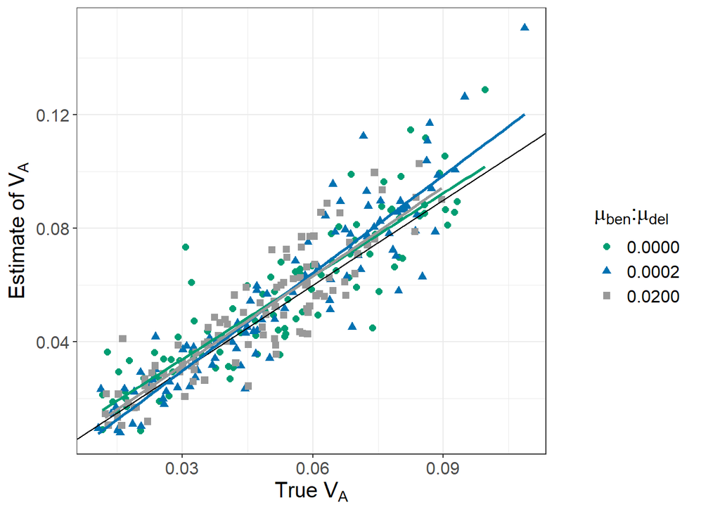

```r
d_11 = read.csv(file.path(data_path, "Set_11_corrected_output.csv")) # Data for the set with mut_ratio = 0.0002
d_14 = read.csv(file.path(data_path, "Set_14_corrected_output.csv")) # Data for the set with mut_ratio = 0.02


# Add calculations of vA_true_new, va_true_new, va_lost, va_lost_new
d_11 = add_new_va_data(new_va_data=d_new_va, target_data=d_11, verbose=TRUE)

# Add calculations of vA_true_new, va_true_new, va_lost, va_lost_new
d_14 = add_new_va_data(new_va_data=d_new_va, target_data=d_14, verbose=TRUE)

# Combined plot for proportion of beneficial mutations

p_ben_0.033 = ggplot(rbind(d_9_std, d_11, d_14), aes(y = vA_est, x = vA_true_new, color = factor(format(mut_ratio, scientific = FALSE)), shape = factor(format(mut_ratio, scientific = FALSE)))) +
  theme_bw() +
  geom_point(size = 2) +
  geom_abline(intercept = 0, slope = 1) +
  labs(x = TeX(r"(True $V_A$)"), y = TeX(r"(Estimate of $V_A$)"), color = TeX(r"($\mu_{ben} : \mu_{del}$)"), shape = TeX(r"($\mu_{ben} : \mu_{del}$)")) +
  scale_color_manual(values = c("#009E73", "#0072B2", "#999999")) +
  theme(text = element_text(size = 15)) +
  geom_smooth(method = "lm", se=FALSE, show.legend = FALSE) +
  theme(plot.title = element_text(hjust = 0.5))

legend_ben = get_legend(p_ben_0.033)
p_ben_0.033 = plot_grid(p_ben_0.033 + theme(legend.position = "none"),
                        legend_ben,
                        ncol = 2,
                        rel_widths = c(1, 0.3))
p_ben_0.033
```

### Varying the map length in the experiment phase (scale = 0.033): ml_exp = c(0.01, 0.2, 2), mut_ratio = 0 (Figure 4A)

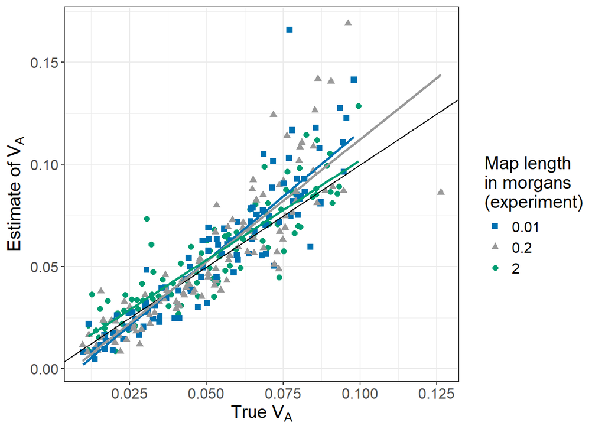

```r
d_12 = read.csv(file.path(data_path, "Set_12_corrected_output.csv")) # Data when ml_exp was varied for scale = 0.033


# Add calculations of vA_true_new, va_true_new, va_lost, va_lost_new
d_12 = add_new_va_data(new_va_data=d_new_va, target_data=d_12, verbose=TRUE)

d_ml_exp = rbind(d_9_std, d_12)

p_ml_exp_0.033 = ggplot(d_ml_exp , aes(y=vA_est, x = vA_true_new, color = factor(sequence_length*r_expt), shape = factor(sequence_length*r_expt))) +
  theme_bw() +
  geom_point(size = 2) +
  geom_abline(intercept = 0, slope = 1) +
  labs(x = TeX(r"(True $V_A$)"), y = TeX(r"(Estimate of $V_A$)"), color = "Map length \nin morgans \n(experiment)", shape = "Map length \nin morgans \n(experiment)") +
  scale_color_manual(values = c("#0072B2", "#999999", "#009E73")) + scale_shape_manual(values = c(15, 17, 16)) +
  theme(text = element_text(size = 15)) +
  geom_smooth(method = "lm", se=FALSE, show.legend = FALSE) +
  theme(plot.title = element_text(hjust = 0.5))


# When combining such plots, varying legend sizes can result in misaligned plots
# Standardising the size of the plot and the space allocated to the legend by extracting the legend and then combining the legend-less plot and the legend in a standardised way

legend_ml_exp_0.033 = get_legend(p_ml_exp_0.033)
p_ml_exp_0.033 = plot_grid(p_ml_exp_0.033 + theme(legend.position = "none"),
                           legend_ml_exp_0.033,
                           ncol = 2,
                           rel_widths = c(1, 0.3))
p_ml_exp_0.033
```

### Varying the scale of the gamma distribution from which mutations are drawn in the simulation (deleterious mutations only) (scale = c(0.033, 0.045, 0.1)) (Figure 4D)

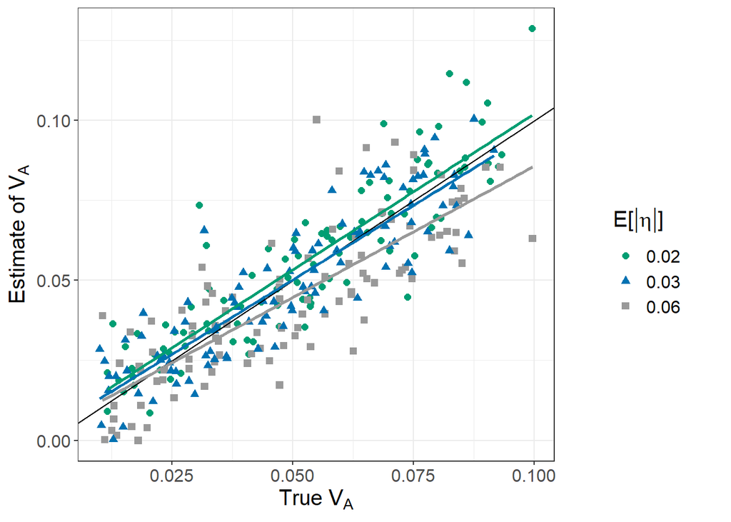

```r
# Load the data for Set_15 in which mut_ratio was 0.0002 and 0.02
d_15 = read.csv(file.path(data_path, "Set_15_corrected_output.csv"))


# Add calculations of vA_true_new, va_true_new, va_lost, va_lost_new
d_15 = add_new_va_data(new_va_data=d_new_va, target_data=d_15, verbose=TRUE)
# Combine with the data of the standard set i.e. mut_ratio = 0
d_scale = rbind(d_9_std, d_15)
# Some simulations were erroneously analysed twice, in such case retain only the first analysis
d_scale = deduplicate_sim_analyses(d_scale)

p_scale = ggplot(d_scale , aes(y=vA_est, x = vA_true_new, color = factor(round(2*scale*shape, 2)), shape = factor(round(2*scale*shape, 2)))) +
  theme_bw() +
  geom_point(size = 2) +
  geom_abline(intercept = 0, slope = 1) +
  labs(x = TeX(r"(True $V_A$)"), y = TeX(r"(Estimate of $V_A$)"), color = TeX(r"($E[|\eta|]$)"), shape = TeX(r"($E[|\eta|]$)")) +
  scale_color_manual(values = c("#009E73", "#0072B2","#999999")) +
  theme(text = element_text(size = 15)) +
  geom_smooth(method = "lm", se=FALSE, show.legend = FALSE) +
  theme(plot.title = element_text(hjust = 0.5))

# When combining such plots, varying legend sizes can result in misaligned plots
# Standardising the size of the plot and the space allocated to the legend by extracting the legend and then combining the legend-less plot and the legend in a standardised way

legend_scale = get_legend(p_scale)
p_scale = plot_grid(p_scale + theme(legend.position = "none"),
                    legend_scale,
                    ncol = 2,
                    rel_widths = c(1, 0.3))
p_scale
```

### Varying the map length in the history phase (ml = c(0.5, 5, 50, 250)) (Figure 4B)

```r
d_13 = read.csv(file.path(data_path, "Set_13_corrected_output.csv"))

# Add calculations of vA_true_new, va_true_new, va_lost, va_lost_new
d_13 = add_new_va_data(new_va_data=d_new_va, target_data=d_13, verbose=TRUE)
```

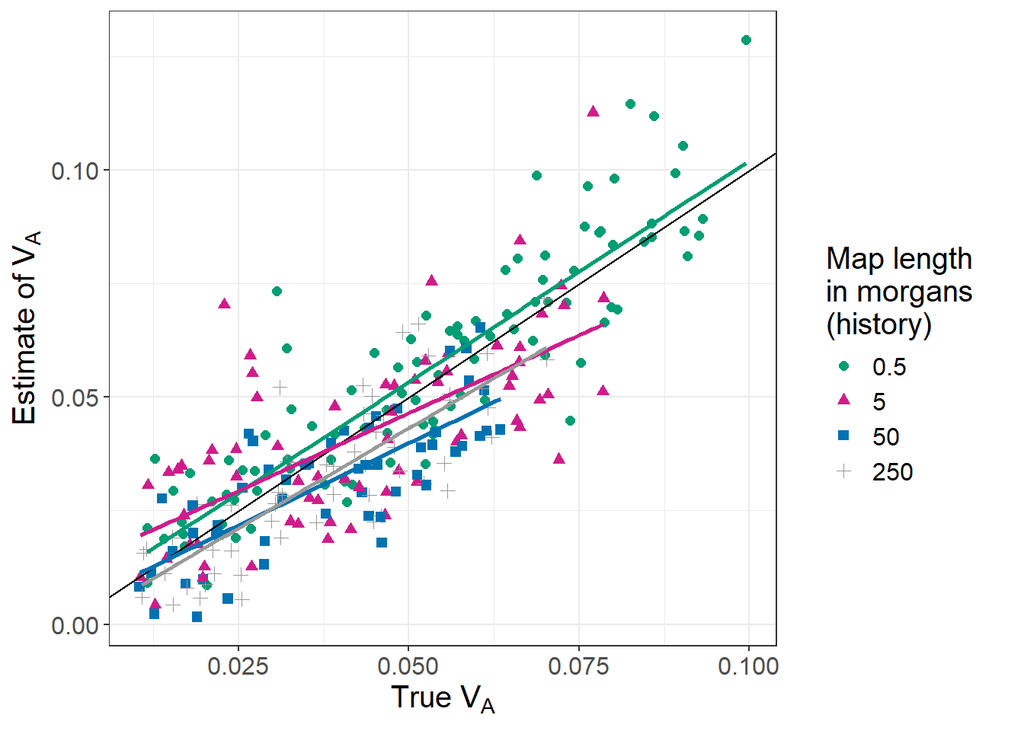

```r
# Combine with the standard data set

d_ml_history = rbind(d_9_std, d_13)

p_b_0.033_ml = ggplot(d_ml_history , aes(y=vA_est, x = vA_true_new, color = factor(sequence_length*r), shape = factor(sequence_length*r))) +
  theme_bw() +
  geom_point(size = 2) +
  geom_abline(intercept = 0, slope = 1) +
  labs(x = TeX(r"(True $V_A$)"), y = TeX(r"(Estimate of $V_A$)"), color = "Map length \nin morgans \n(history)", shape = "Map length \nin morgans \n(history)") +
  scale_color_manual(values = c("#009E73", "#D01C8B", "#0072B2", "#999999")) +
  theme(text = element_text(size = 15)) +
  geom_smooth(method = "lm", se=FALSE, show.legend = FALSE) +
  theme(plot.title = element_text(hjust = 0.5))

# When combining such plots, varying legend sizes can result in mesaligned plots
# Standardising the size of the plot and the space allocated to the legend by extractig the legend and then combining the legend-less plot and the legend in a standardised way

legend_b_0.033_ml = get_legend(p_b_0.033_ml)
p_b_0.033_ml = plot_grid(p_b_0.033_ml + theme(legend.position = "none"),
                           legend_b_0.033_ml,
                           ncol = 2,
                           rel_widths = c(1, 0.3))
p_b_0.033_ml
```

## The standard set of full simulations (with burnin) (scale = 0.033) analysed with all.gp = FALSE (standard) or all.gp = TRUE (gametic phase LD not used) (Figure 4E)

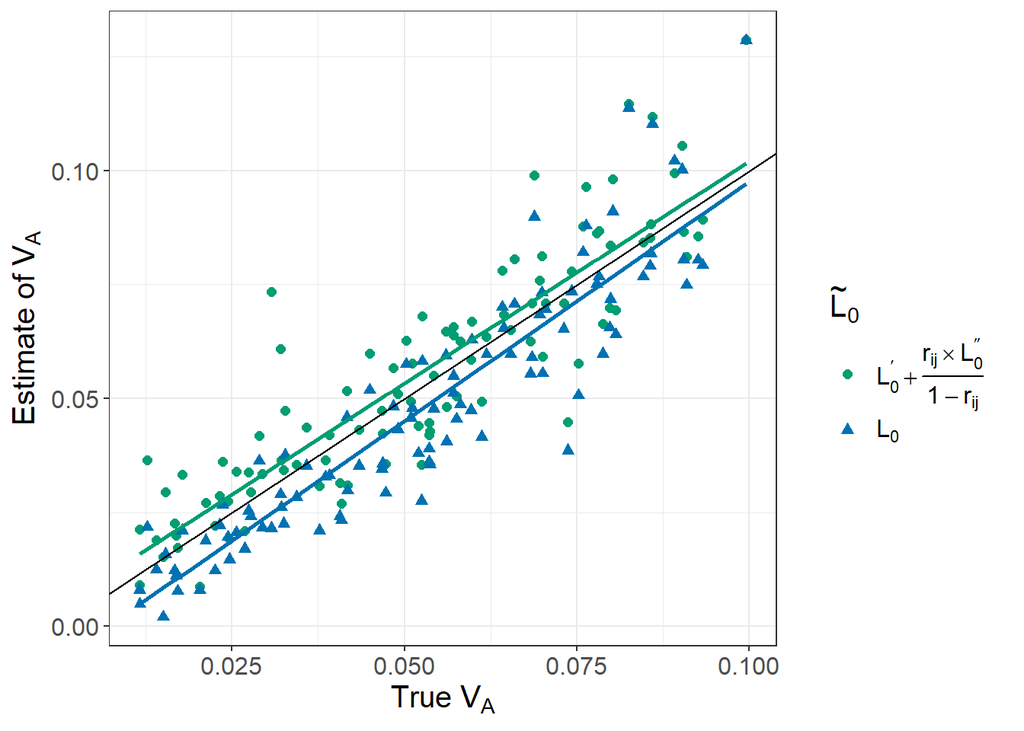

```r
d_9_nstd = d_9[d_9$all.gp==TRUE&d_9$Ne_exp!="1000_1000",]

# In d_9_nstd there are some simulations that were analysed twiced
# Retaining only the analysis performed first

d_9_nstd = deduplicate_sim_analyses(d_9_nstd)

# Combine with the standard data set (i.e. analyses in which all.gp=FALSE)
d_all.gp = rbind(d_9_std, d_9_nstd)

all.gp_labs = c(TeX(r"(${\bf L}^{'}_{0} + \frac{ r_{ij} \times{\bf L}^{''}_{0}}{1-r_{ij}}$)"), TeX(r"($\bf L_0$)"))
names(all.gp_labs) = c(FALSE, TRUE)

p_all.gp = ggplot(d_all.gp, aes(y = vA_est, x = vA_true_new, color = all.gp, shape = all.gp)) +
  theme_bw() +
  geom_point(size = 2) +
  geom_abline(intercept = 0, slope = 1) +
  labs(x = TeX(r"(True $V_A$)"), y = TeX(r"(Estimate of $V_A$)"), color = TeX(r"($\tilde{\bf L}_0$)"), shape = TeX(r"($\tilde{\bf L}_0$)")) +
  scale_color_manual(values = c("#009E73", "#0072B2"), labels = all.gp_labs) + scale_shape_manual(values = c(16, 17), labels = all.gp_labs) +
  theme(text = element_text(size = 15)) +
  geom_smooth(method = "lm", se=FALSE, show.legend = FALSE) +
  theme(plot.title = element_text(hjust = 0.5))

# When combining such plots, varying legend sizes can result in mesaligned plots
# Standardising the size of the plot and the space allocated to the legend by extractig the legend and then combining the legend-less plot and the legend in a standardised way

legend_all.gp = get_legend(p_all.gp)
p_all.gp = plot_grid(p_all.gp + theme(legend.position = "none"),
                     legend_all.gp,
                     ncol = 2,
                     rel_widths = c(1, 0.3))
p_all.gp
```

## The standard set of full simulations (with burnin) (scale = 0.033) analysed with Ne = nind = 1000 (Figure 4F)

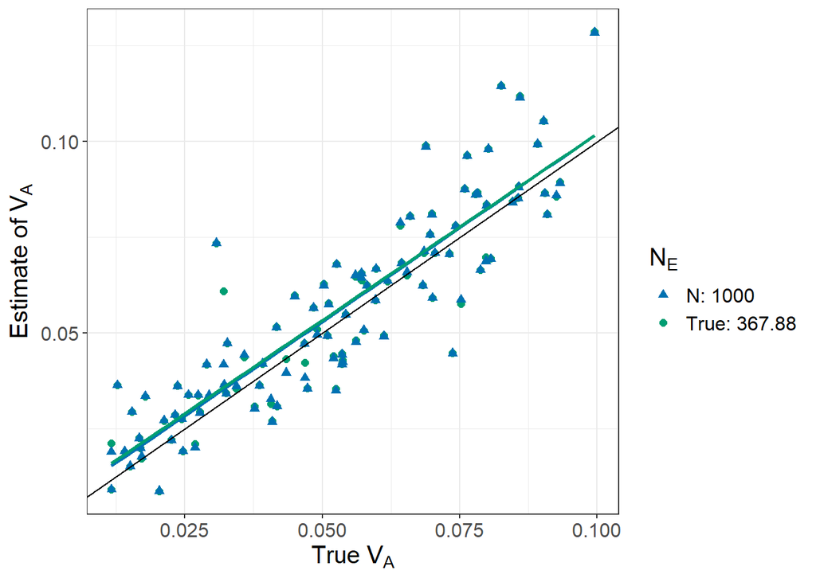

```r
d_9_fixed_Ne = d_9[d_9$all.gp==FALSE&d_9$Ne_exp=="1000_1000",]

d_9_Ne = rbind(d_9_std, d_9_fixed_Ne)

# The Ne_exp contains the Ne in as a vector of length two separated by "_". The first element is the Ne in the first generation after the parents generation when there is no selection. The second element is the Ne in between ngen1 to ngen2 when selection operates. Here we select only the element 2.

# Create labels for Ne_type
Ne_type = unique(d_9_Ne$Ne_exp)
Ne_type_labs = rep(NA, length(Ne_type))

for(i in 1:length(Ne_type)){
  Ne_type_labs[i] = round(as.numeric(unlist(strsplit(Ne_type[i], "_"))[2]), 2)
  nind_exp = unique(d_9_Ne[d_9_Ne$Ne_exp==Ne_type[i],]$n_ind_exp)

  if(Ne_type_labs[i]==nind_exp){
    Ne_type_labs[i] = paste("N:", Ne_type_labs[i])
  }else{
      Ne_type_labs[i] = paste("True:", Ne_type_labs[i])
      }
}

names(Ne_type_labs) = Ne_type

p_Ne = ggplot(d_9_Ne, aes(y = vA_est, x = vA_true_new, color = Ne_exp, shape = Ne_exp)) +
  theme_bw() +
  geom_point(size = 2) +
  geom_abline(intercept = 0, slope = 1) +
  labs(x = TeX(r"(True $V_A$)"), y = TeX(r"(Estimate of $V_A$)"), color = TeX(r"($N_E$)"), shape =  TeX(r"($N_E$)")) +
  scale_color_manual(values = c("#0072B2", "#009E73"), labels = Ne_type_labs) +
  scale_shape_manual(values = c(17, 16), labels = Ne_type_labs) +
  theme(text = element_text(size = 15)) +
  geom_smooth(method = "lm", se=FALSE, show.legend = FALSE) +
  theme(plot.title = element_text(hjust = 0.5))

legend_Ne = get_legend(p_Ne)
p_Ne = plot_grid(p_Ne + theme(legend.position = "none"),
                 legend_Ne,
                 ncol = 2,
                 rel_widths = c(1, 0.3))
#################
### Figure S3 ###
#################

# plot residual variance

p_Ne_res = ggplot(d_9_Ne, aes(y = Residual_var, x = Ne_exp)) +
  theme_bw() +
  geom_boxplot() +
  labs(y = "Residual variance", x = TeX(r"($N_E$)")) +
  scale_x_discrete(labels = Ne_type_labs) +
  theme(text = element_text(size = 15))

ggsave(p_Ne_res, width = 5, height = 5, file = file.path(output_path, "residual_var_NE.pdf"))

p_Ne
```

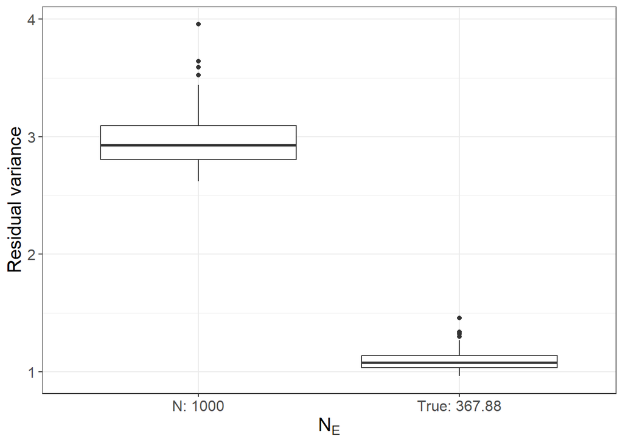

```r
p_Ne_res
```